# hvCpG_BayesAlgo_exploration

Alice Balard

2025-06-30

```r
knitr::opts_chunk$set(echo = TRUE)
invisible(lapply(
  c("dplyr", "data.table", "matrixStats", "ggplot2", "reshape2",
    "ggrepel", "pROC", "stringr", "tibble", "viridis", "ggridges"),
  function(pkg) suppressPackageStartupMessages(library(pkg, character.only = TRUE))
))
```

# Data prep

```r
##########################################################################################
## LSHTM: Maria’s data that she used for the hvCpG paper can be accessed from ing-p5 here:
# /mnt/old_user_accounts/p3/maria/PhD/Data/datasets/
#
# Her hvCpG scripts are here:
# /mnt/old_user_accounts/p3/maria/PhD/Projects/hvCpGs/Scripts/

source("../03_prepDatasetsMaria/dataprep_MariaArrays.R")
my_list_mat <- Maria_filtered_list_mat; rm(Maria_filtered_list_mat)
cpgnames <- unique(unlist(sapply(my_list_mat, row.names)))
cpgnames <- cpgnames[order(cpgnames)]
```

# Reproduce Maria’s results

Maria’s paper: We defined an hvCpG in the following way:

1. in 65% of datasets in which the CpG is covered (following quality control), it has methylation variance in the top 5% of all (non-removed) CpGs.
2. is covered in at least 15 of the 30 datasets.

```r
## Within each dataset, calculate the CpGs variance, and keep the top 5%
top5pcvar <- lapply(my_list_mat, function(mat) {
  # Step 1: Calculate row variances
  row_variances = rowVars(mat, na.rm = T)
  df = data.frame(var=row_variances, cpg=names(row_variances))
  # Step 2
  top = top_n(df, as.integer(0.05*nrow(df)), var) ## slightly different than quantile cause keep ties
  return(top)
})

## CpGs in the top 5% variance:
cpg_counts_top <- table(unlist(lapply(top5pcvar, rownames))) %>%
  data.frame() %>% dplyr::rename("cpgs"="Var1", "all_cpgs_top5pc"="Freq")

## all covered CpGs:
cpg_counts <- table(unlist(lapply(my_list_mat, rownames))) %>%
  data.frame() %>% dplyr::rename("cpgs"="Var1", "all_cpgs"="Freq")

## Both:
cpg_counts_full <- merge(cpg_counts, cpg_counts_top, all.x = T)
rm(cpg_counts, cpg_counts_top)

## in 65% of datasets in which the CpG is covered (following quality control), it has methylation variance in the top 5% of all (non-removed) CpGs:
hvCpGs_maria <- na.omit(cpg_counts_full[cpg_counts_full$all_cpgs_top5pc/cpg_counts_full$all_cpgs >= 0.65,])

## rounding, to mimick Maria's approach
hvCpGs_maria <- na.omit(cpg_counts_full[round(cpg_counts_full$all_cpgs_top5pc/cpg_counts_full$all_cpgs, 2) >= 0.65,])
```

Maria detected 4143 hvCpGs. I detected 4377 hvCpGs. We both have 4143 hvCpGs in common.

# Identify hvCpGs based on a sd multiplicative factor lambda

The proportion of CpGs than Maria found hvCpGs is p(hvCpG) = 1.02%.

## Calculate lambda

Within each dataset k, calculate the median sd of all CpG j

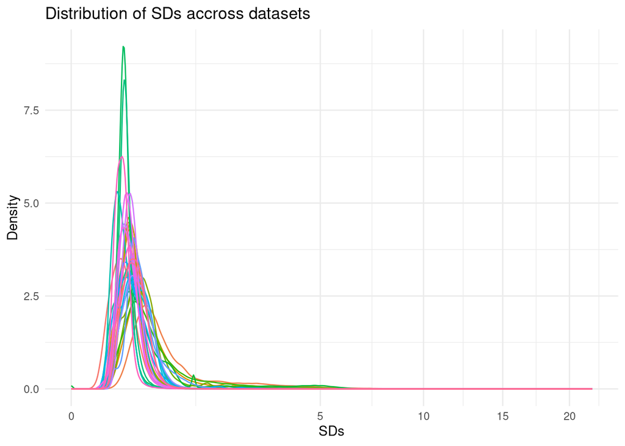

```r
all_sd_jk <- sapply(my_list_mat, function(k){

  ## Scale
  k = log2(k/(1-k))

  get_sd_k <- function(k){
    ## Calculate a vector of the row (=per CpG j) sd
    return(rowSds(k, na.rm = T))
  }
  ## Return a vector of sds, in a list for each dataset
  return(get_sd_k(k))
})

## Plot:
df_long <- reshape2::melt(all_sd_jk, variable.name = "Vector", value.name = "SDs")

## Plot distributions of all vectors on the same graph
ggplot(df_long, aes(x = SDs, color = L1)) +
  geom_density() +
  labs(title = "Distribution of SDs accross datasets",
       x = "SDs",
       y = "Density") +
  theme_minimal() +
  theme(legend.position = "none") +
  scale_x_sqrt()
```

```r
## Calculate lambda per dataset
lambdas = sapply(all_sd_jk, function(x){quantile(x, 0.95, na.rm=T)/median(x, na.rm=T)})
names(lambdas) <- gsub(".95%", "", names(lambdas))
```

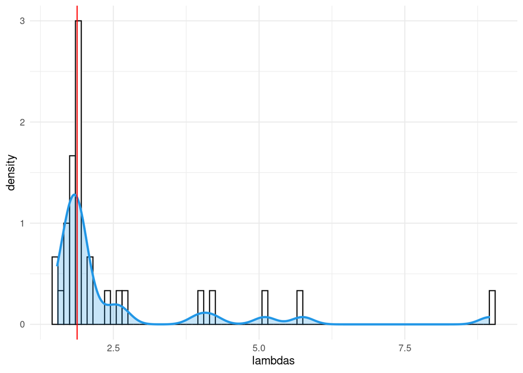

```r
# Histogram with kernel density
ggplot(data.frame(lambda=lambdas, dataset=names(lambdas)),
       aes(x = lambdas)) +
  geom_histogram(aes(y = after_stat(density)),
                 colour = 1, fill = "white", binwidth = .1) +
  geom_density(lwd = 1, colour = 4,
               fill = 4, alpha = 0.25)+
  theme_minimal() +
  geom_vline(xintercept = median(lambdas), col = "red")
```

```r
median(lambdas) #1.878303
```

```
## [1] 1.878303
```

Which datasets have a higher lambda, and why?

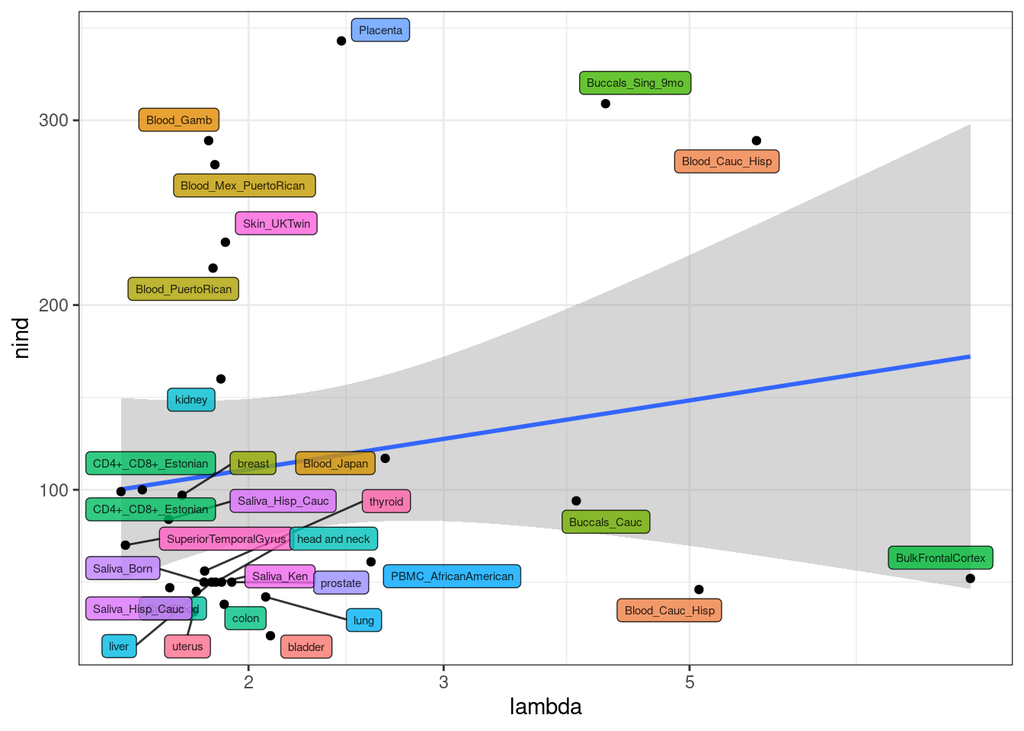

```r
df = data.frame(nind=sapply(my_list_mat, ncol),
                dataset=names(my_list_mat),
                lambda=lambdas,
                tissue = sapply(strsplit(names(my_list_mat), "_"), `[`, 1),
                ethnicity=sapply(strsplit(names(my_list_mat), "_"), `[`, 2)) %>%
  mutate(dataset=ifelse(dataset %in% c("Blood_Cauc", "Blood_Hisp"), "Blood_Cauc_Hisp", dataset)) %>%
  mutate(dataset=ifelse(dataset %in% c("Blood_Mexican", "Blood_PuertoRican "), "Blood_Mex_PuertoRican ", dataset)) %>%
  mutate(dataset=ifelse(dataset %in% c("CD4+_Estonian", "CD8+_Estonian"), "CD4+_CD8+_Estonian", dataset)) %>%
  mutate(dataset=ifelse(dataset %in% c("Saliva_Hisp", "Saliva_Cauc"), "Saliva_Hisp_Cauc", dataset))

ggplot(data = df,
       aes(x=lambda, y=nind))+
  geom_smooth(method = "lm")+
  geom_point()+
  geom_label_repel(aes(label = dataset, fill=dataset), size= 2, alpha=.8, max.overlaps = 25)+
  theme_bw()+theme(legend.position = "none")+
  scale_x_log10()
```

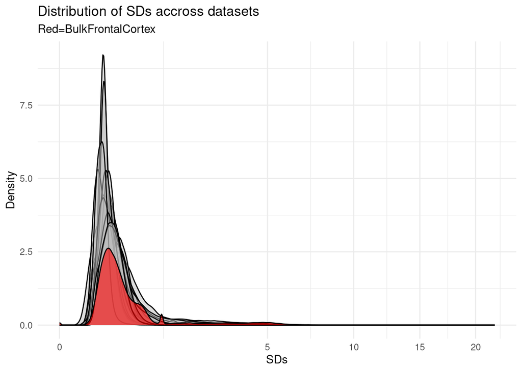

```r
## Emphasize the outliers
df_long$col = "grey"
df_long$col[df_long$L1 %in% "BulkFrontalCortex"] <- "red"

ggplot(df_long, aes(x = SDs, group = L1, fill = col)) +
  geom_density(data = df_long[!df_long$L1 %in% "BulkFrontalCortex",], alpha = .5) +
  geom_density(data = df_long[df_long$L1 %in% "BulkFrontalCortex",], alpha = .6) +
  scale_fill_manual(values = c("grey", "red"))+
  labs(title = "Distribution of SDs accross datasets",subtitle = "Red=BulkFrontalCortex",
       x = "SDs",
       y = "Density") +
  theme_minimal() +
  theme(legend.position = "none") +
  scale_x_sqrt()
```

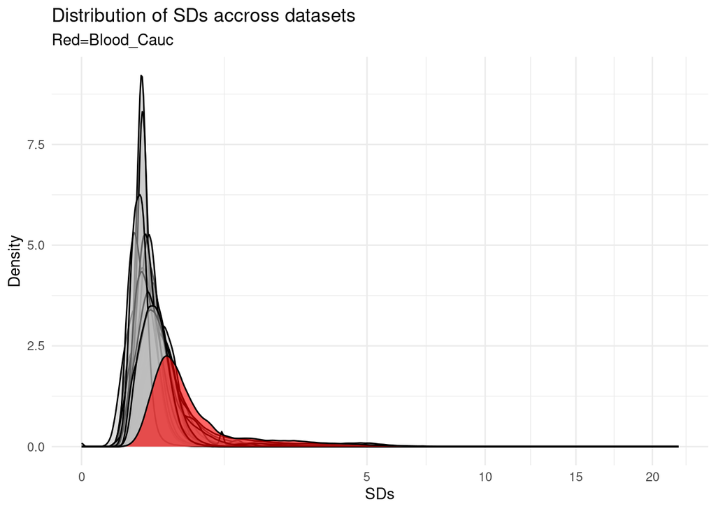

```r
## Emphasize the outliers
df_long$col = "grey"
df_long$col[df_long$L1 %in% "Blood_Cauc"] <- "red"

ggplot(df_long, aes(x = SDs, group = L1, fill = col)) +
  geom_density(data = df_long[!df_long$L1 %in% "Blood_Cauc",], alpha = .5) +
  geom_density(data = df_long[df_long$L1 %in% "Blood_Cauc",], alpha = .6) +
  scale_fill_manual(values = c("grey", "red"))+
  labs(title = "Distribution of SDs accross datasets",subtitle = "Red=Blood_Cauc",
       x = "SDs",
       y = "Density") +
  theme_minimal() +
  theme(legend.position = "none") +
  scale_x_sqrt()
```

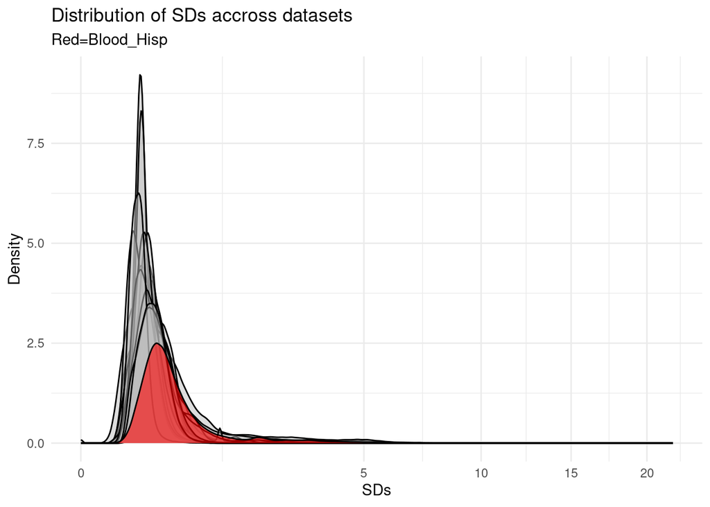

```r
## Emphasize the outlier
df_long$col = "grey"
df_long$col[df_long$L1 %in% "Blood_Hisp"] <- "red"

ggplot(df_long, aes(x = SDs, group = L1, fill = col)) +
  geom_density(data = df_long[!df_long$L1 %in% "Blood_Hisp",], alpha = .5) +
  geom_density(data = df_long[df_long$L1 %in% "Blood_Hisp",], alpha = .6) +
  scale_fill_manual(values = c("grey", "red"))+
  labs(title = "Distribution of SDs accross datasets",subtitle = "Red=Blood_Hisp",
       x = "SDs",
       y = "Density") +
  theme_minimal() +
  theme(legend.position = "none") +
  scale_x_sqrt()
```

# Maximum likelihood analysis

The equation is:

$$\log\left(P(M_j)\right) = \sum_{i=1}^{n} \log\left( \sum_{Z_j=0}^{1}
\left( \sum_{Z_{j,k}=0}^{1} P(M_{i,j} \mid Z_{j,k}) \times P(Z_{j,k}
\mid Z_j) \right) \times P(Z_j) \right)$$

## Examine weird values

The transformation lead to weird values:

```r
# my_list_mat$Blood_Hisp[rownames(my_list_mat$Blood_Hisp) %in% "cg23089912",1:10]
# scaled_list_mat$Blood_Hisp[rownames(scaled_list_mat$Blood_Hisp) %in% "cg23089912",1:10]
#
# test <- readRDS("/mnt/old_user_accounts/p3/maria/PhD/Data/datasets/GEO/Raw_cleaned_beta_matrices_GEO/Blood_Hisp")
# test[rownames(test) %in% "cg23089912",5:10]
#
# test <- readRDS("/mnt/old_user_accounts/p3/maria/PhD/Data/datasets/GEO/BMIQ + 10 PCs + age + sex OUTLIERS REMOVED/Blood_Hisp.RDS")
# test[rownames(test) %in% "cg23089912",5:10]
# # GSM1870986
# # 0.00000000000000001124546 --> give extreme value in scaling, and p dnorm=0
```

The zero in 8h sample was weirdly transformed. The cleaned values are very different from the original. Is that expected?

## Optimisation over multiple CpGs

Run on LSHTM server (need to be outside of RStudio): source(“S01_run_hvCpGdetection_Marias.R”) ## for different datasets

### “Nelder-Mead” or “L-BFGS-B” optimisation method?

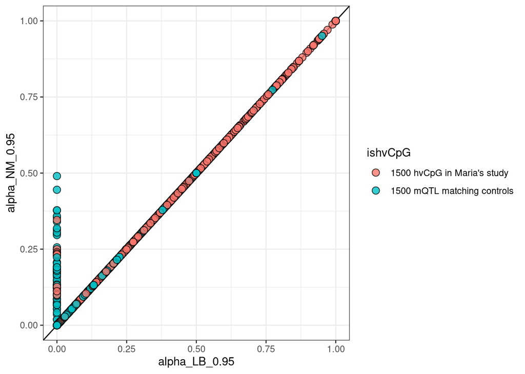

```r
## TO DO load the good one when have ran (to run after the apply)

load("/home/alice/2024_hvCpG/05_hvCpGalgorithm/resultsDir/results_Nelder_Mead_my_list_mat_Mariads_test3000CpGsvec_0_95p0_0_65p1.RData")
A <- results_Nelder_Mead_my_list_mat_Mariads_test3000CpGsvec_0_95p0_0_65p1 %>% data.frame %>% tibble::rownames_to_column("CpG") %>% dplyr::rename(alpha_NM_0.95="alpha_hat")

load("/home/alice/2024_hvCpG/05_hvCpGalgorithm/resultsDir/results_L_BFGS_B_my_list_mat_Mariads_test3000CpGsvec_0_95p0_0_65p1.RData")
B <- results_L_BFGS_B_my_list_mat_Mariads_test3000CpGsvec_0_95p0_0_65p1 %>%
  data.frame %>% tibble::rownames_to_column("CpG") %>% dplyr::rename(alpha_LB_0.95="alpha_hat")

merge(A, B, by = "CpG") -> results_test3000_0.95
results_test3000_0.95 %>% mutate(ishvCpG = ifelse(CpG %in% MariasCpGs$CpG,
                                                  "1500 hvCpG in Maria's study", "1500 mQTL matching controls")) %>% ggplot(aes(x=alpha_LB_0.95, y=alpha_NM_0.95, fill = ishvCpG)) +
  geom_abline(slope = 1) +
  geom_point(pch=21, size = 3, alpha = .8) +
  theme_bw()
```

Some CpGs have an alpha of 0 for LBB algorithm and different alpha for NM

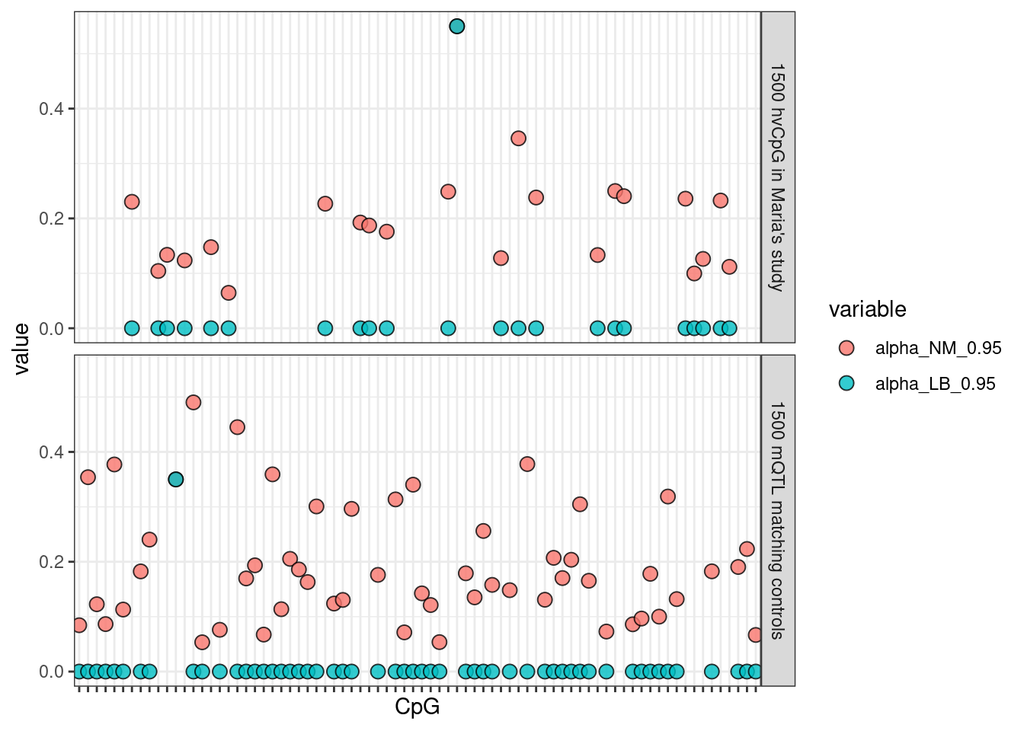

```r
results_test3000_0.95[round(results_test3000_0.95$alpha_NM_0.95, 1) != round(results_test3000_0.95$alpha_LB_0.95, 1),] %>% mutate(ishvCpG = ifelse(CpG %in% MariasCpGs$CpG, "1500 hvCpG in Maria's study", "1500 mQTL matching controls")) %>% melt() %>%
  ggplot(aes(x=CpG, y=value, fill = variable)) +
  geom_point(pch=21, size = 3, alpha = .8) +
  facet_grid(ishvCpG~.) + theme_bw() + theme(axis.text.x = element_blank())
```

The probability of zero seems to be an artefact of the “L-BFGS-B” optimisation method, so we choose “Nelder-Mead”.

## ROC curves to define p0 and p1 matching Maria’s approach

$$p0 = P(Z_{j,k}=0 \mid Z_j=0) \\
p1 = P(Z_{j,k}=1 \mid Z_j=1)$$
p1 = 0.65 in Maria’s approach (to be a hvCpG, it needs to be hypervariable in >65% of the datasets)

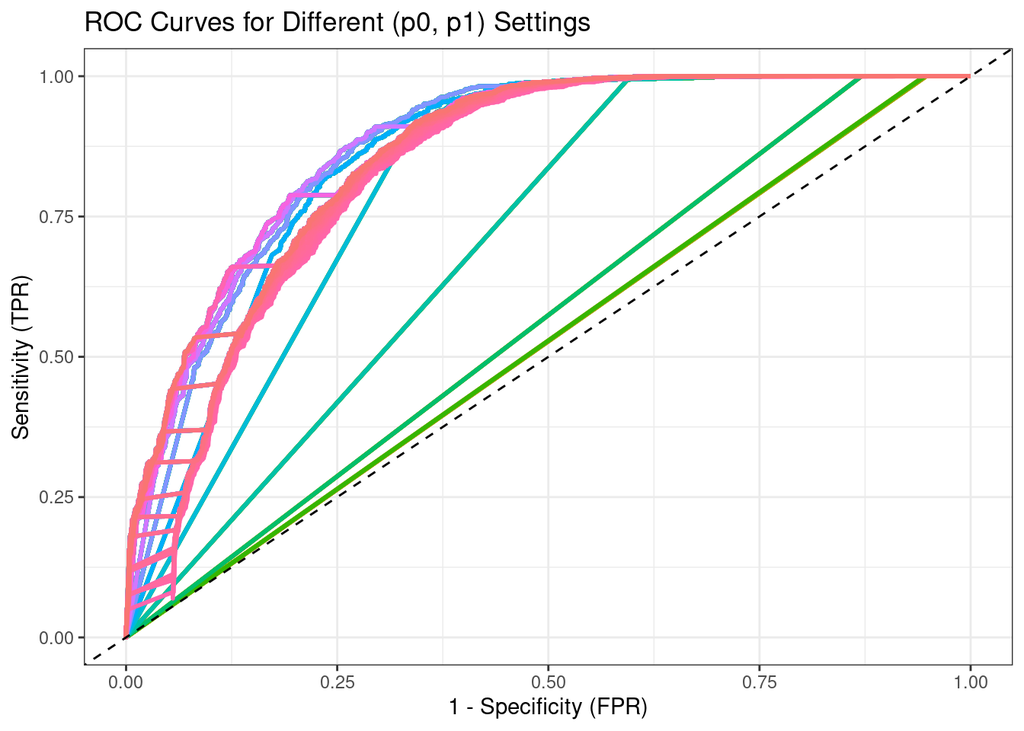

```r
# List all result files
files <- list.files(
  "resultsDir",
  pattern = "^results_Nelder_Mead_my_list_mat_Mariads_test3000CpGsvec_.*\\.RData$",
  full.names = TRUE
)

# Initialize containers
auc_results <- data.frame(p0 = numeric(), p1 = numeric(), AUC = numeric())
roc_list <- list()

for (file in files) {
  # Correct: load the current file
  loaded_obj_name <- load(file)
  result_obj <- get(loaded_obj_name)

  # Correct: match p0 and p1 from the **file name**, not the object!
  p_str <- str_match(file, "_(\\d+(?:_\\d+)?)p0_(\\d+(?:_\\d+)?)p1")[, 2:3]
  p0 <- as.numeric(gsub("_", ".", p_str[1]))
  p1 <- as.numeric(gsub("_", ".", p_str[2]))
  label <- paste0("p0=", p0, ", p1=", p1)

  df <- as.data.frame(result_obj) %>%
    rownames_to_column("CpG")

  # Always rename first column to `alpha`
  colnames(df)[2] <- "alpha"

  # True/false labels
  alpha_vector <- df$alpha
  truth_vector <- ifelse(df$CpG %in% MariasCpGs$CpG, 1, 0)

  # ROC + AUC
  roc_obj <- roc(response = truth_vector, predictor = alpha_vector, quiet = TRUE)
  auc_val <- as.numeric(auc(roc_obj))

  # Store AUC summary
  auc_results <- rbind(auc_results, data.frame(p0 = p0, p1 = p1, AUC = auc_val))

  # Store ROC curve
  roc_df <- coords(roc_obj, x = "all", ret = c("sensitivity", "specificity"), transpose = FALSE)
  roc_df <- mutate(roc_df, FPR = 1 - specificity, TPR = sensitivity, label = label)
  roc_list[[label]] <- roc_df
}

# Combine all ROC curves
all_roc_df <- bind_rows(roc_list)

p_roc <- ggplot(all_roc_df, aes(x = FPR, y = TPR, color = label)) +
  geom_line(size = 1) +
  geom_abline(slope = 1, linetype = "dashed") +
  labs(title = "ROC Curves for Different (p0, p1) Settings",
       x = "1 - Specificity (FPR)",
       y = "Sensitivity (TPR)",
       color = "Parameters") +
  # guides(color = guide_legend(ncol = 3)) +
  theme_bw() + theme(legend.position = "none")
# ==== HEATMAP OF AUCs ====
best <- auc_results %>% arrange(desc(AUC)) %>% slice(1)

p_heatmap <- ggplot(auc_results, aes(x = p0, y = p1, fill = AUC)) +
  geom_tile(color = "white") +
  geom_point(data = best, aes(x = p0, y = p1), color = "red", size = 4) +
  geom_text(data = best, aes(label = paste0("Best AUC=", round(AUC, 3))), vjust = -1, color = "red") +
  scale_fill_viridis_c(option = "plasma") +
  labs(title = "AUC Heatmap by (p0, p1)", x = "p0", y = "p1") +
  theme_minimal()

# ==== SHOW BOTH PLOTS ====
print(p_roc)
```

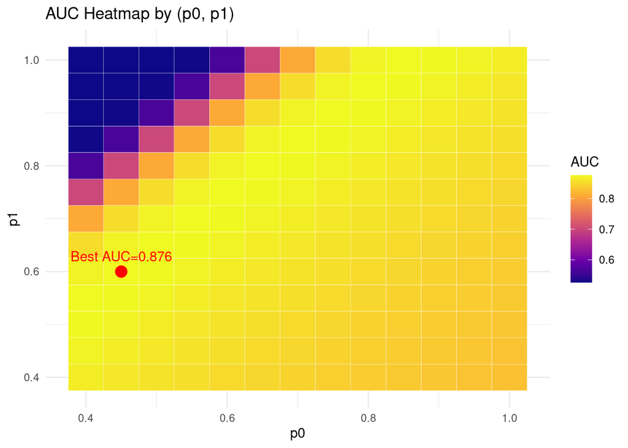

```r
print(p_heatmap)
```

Conclusion: p0 (true negative) is quite low in Maria’s data (0.45)

# Subset Maria’s data following Atlas data structure (less N/dataset) to check power of detection in Atlas data:

3 tries for (p0, p1): - c(0.45, 0.6): best AUC, closest to Maria’s data; low specificity and mid sensitivity - c(0.95, 0.65): our original idea, high specificity but mid sensitivity - c(0.9, 0.9): high specificity and sensitivity

```r
makeMyPlots <-function(p0p1){
  df1 = get(paste0("results_Nelder_Mead_my_list_mat_Mariads_test3000CpGsvec_", p0p1))
  df2 = get(paste0("results_Nelder_Mead_my_list_mat_Mariads_mimicAtlas_test3000CpGsvec_", p0p1))

  p_str = str_match(p0p1, "(\\d+_\\d+)p0_(\\d+_\\d+)p1")[, 2:3]
  p0 = gsub("_", ".", p_str[1])
  p1 = gsub("_", ".", p_str[2])
  label = paste0("p0=", p0, ", p1=", p1)

  plot1 = data.frame(df1, df2) %>%
    tibble::rownames_to_column("CpG") %>%
    mutate(ishvCpG = ifelse(CpG %in% MariasCpGs$CpG, "1500 hvCpG in Maria's study", "1500 mQTL matching controls")) %>%
    dplyr::rename(alpha_normalDS = alpha_hat, alpha_mimicAtlas = alpha_hat.1) %>%
    ggplot(aes(x = alpha_normalDS, y = alpha_mimicAtlas)) +
    geom_point(aes(fill=ishvCpG), pch =21, size =3, alpha = .3) +
    geom_abline(slope = 1, linetype = "dashed") + theme_bw() +
    ggtitle(label = label)

  # === 1) Prepare the ORIGINAL ===
  df_original = df1 %>%
    data.frame() %>%
    tibble::rownames_to_column("CpG") %>%
    mutate(ishvCpG = ifelse(
      CpG %in% MariasCpGs$CpG,
      "1500 hvCpG in Maria's study",
      "1500 mQTL matching controls"
    ),
    source = "original") %>%
    melt()

  # === 2) Prepare the MIMIC ===
  df_mimic = df2 %>%
    data.frame() %>%
    tibble::rownames_to_column("CpG") %>%
    mutate(ishvCpG = ifelse(
      CpG %in% MariasCpGs$CpG,
      "1500 hvCpG in Maria's study",
      "1500 mQTL matching controls"
    ),
    source = "mimicAtlas") %>%
    melt()

  # === 3) Combine ===
  df_combined = bind_rows(df_original, df_mimic)

  # === 4) Plot ===
  plot2 = ggplot(df_combined, aes(x = value, y = ishvCpG, fill = ..x..)) +
    geom_density_ridges_gradient(scale = 3, rel_min_height = .01) +
    facet_wrap(~source, ncol = 1) +
    scale_fill_viridis(name = "alpha", option = "C") +
    theme_bw() +
    theme(axis.title.y = element_blank()) +
    labs(title = "Probability alpha of being hypervariable in my algorithm",
         subtitle = "Original data of Maria vs mimic Atlas structure")

  print(plot1)
  print(plot2)
}
```

## 1. low specificity and mid sensitivity (p0=0.45 and p1=0.6)

### best AUC, my algorithm with the closest proximity to Maria’s approach)

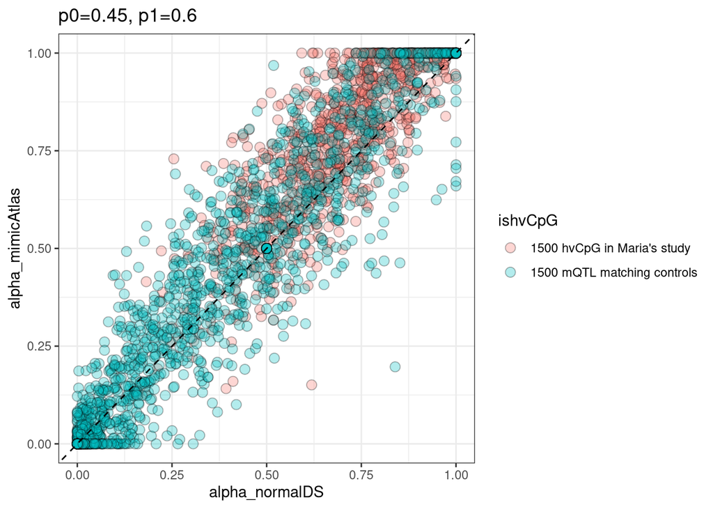

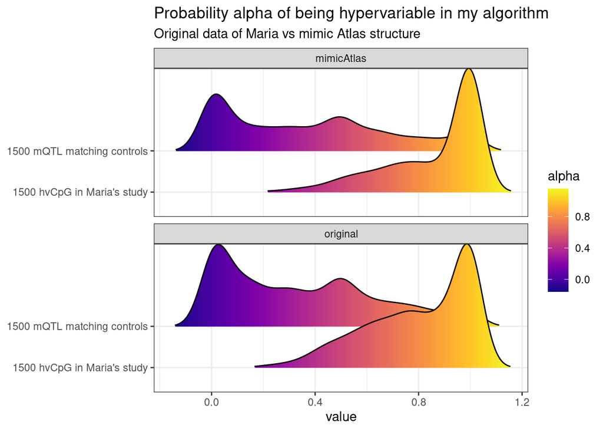

```r
load("resultsDir/results_Nelder_Mead_my_list_mat_Mariads_mimicAtlas_test3000CpGsvec_0_45p0_0_6p1.RData")
makeMyPlots(p0p1 = "0_45p0_0_6p1")
```

## 2. high specificity and mid sensitivity (p0=0.95 and p1=0.65)

### high true negative rate, i.e. high specificity)

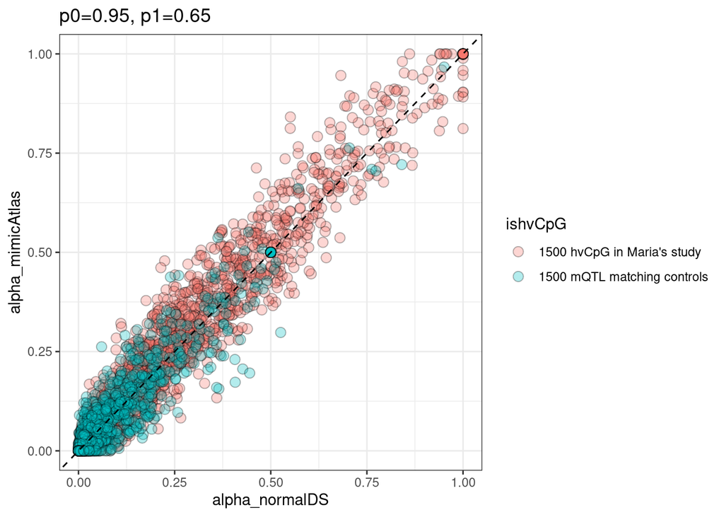

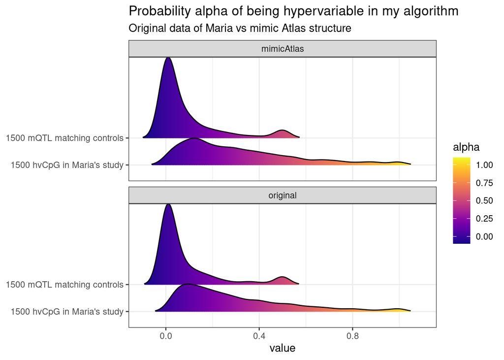

```r
load("resultsDir/results_Nelder_Mead_my_list_mat_Mariads_mimicAtlas_test3000CpGsvec_0_95p0_0_65p1.RData")
makeMyPlots(p0p1 = "0_95p0_0_65p1")
```